# Pantaleo exploratory analysis - TFH095

Kushal K Dey

7/19/2017

# 1 Data Loading & Description

Briefly, paired PBMCs (Peripheral blood mononuclear cells) and LN (Lymph Node) from patients were stained and sorted for TFH (T Follicular Helper) and Live cells. There are three HIV+ CP off treatment and three HIV- patients.

Per patient, per sample, two Seq-Well arrays were processed. *NB: each patient has the following processed array conditions: LN TFH, LN Live, PBMC TFH, & PBMC Live.*

Here - we have four arrays from one HIV- CP patient.

**Obj: Re-perform the analysis // Look at the data.**

Live cells

# 2 Live Cells

## 2.1 Raw Count

Let’s look at the distribution of UMIs and nb. of detected genes in both LN and PBMC samples for Live Cells.

*NB: We do not have information about read distribution.*

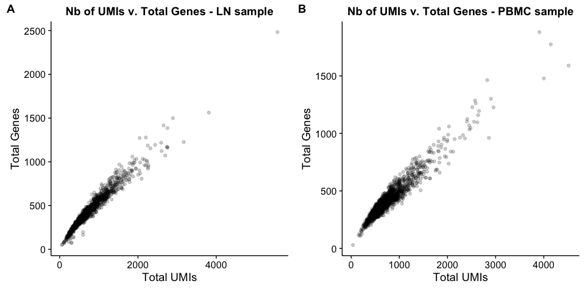

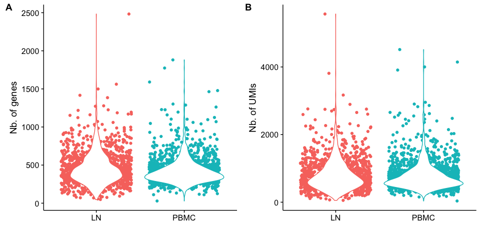

Close nb. of UMIs and detected genes are observed in bith LN and PBMC samples from Live Cells.  
## QC and Filtering

The next step is then to perform quality control and filtering (remove cells with few reads/UMIs or genes, etc.).

The threshold that Sam used was **750 UMIs** and **400 genes** (see *Slides for Pantaleo 053017.ppt* file - HIV+ patient). So, let’s use the same here, and also remove genes with less than one UMI count.

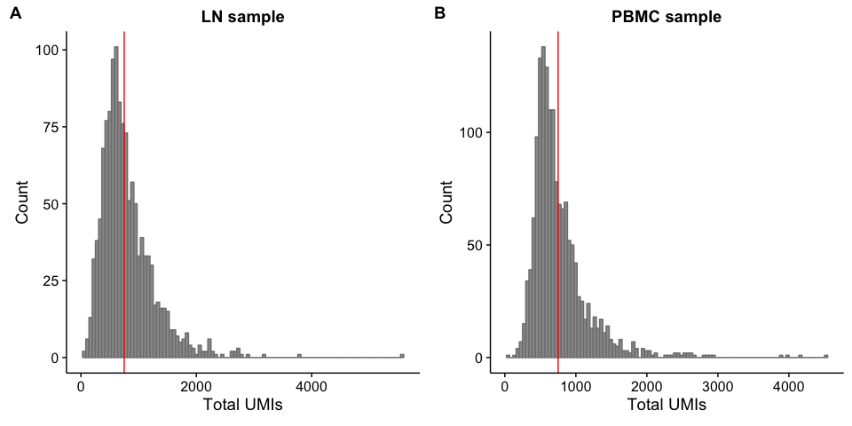

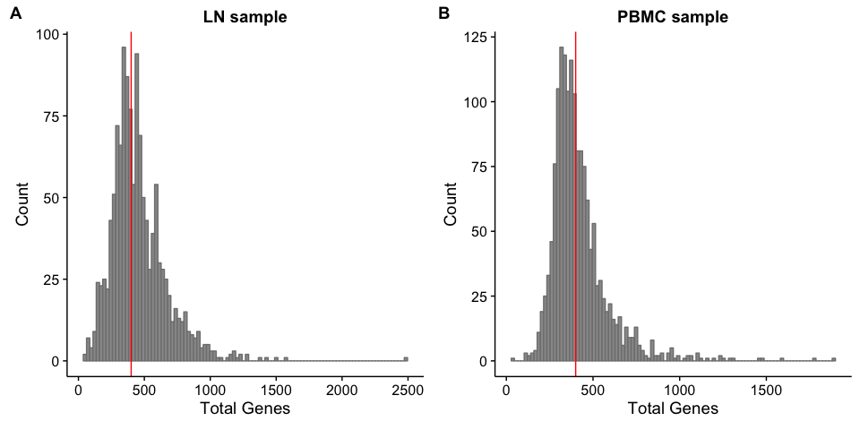

```r
###--- Filtering datasets and merging
#- LN
identical(colnames(LiveCells_LN_UMI), rownames(LiveCells_LN_UMI_summary)) # TRUE
```

```
## [1] TRUE
```